# Bias-Variance Tradeoff

Craig Olson

11/21/2017

## Bias-Variance Tradeoff

This is an overview of Bias Variance Tradeoff (dilemma / decomposition). I provide an overview of what this is, what it looks like, and how to deal with it.

$MSE(\hat\theta) = Bias(\hat\theta)^{2} + Var(\hat\theta)$

We see that the MSE is composed of both the Bias and Variance terms.

Mean Squared Error: $\hat\theta = E[(\hat\theta - \theta)^{2}]$

MSE is the average squared error between each of our estimates and the observed value. It is a common method to measure the accuracy of a model.

In thinking of Bias and Variance, I find it helpful to image a dart board, and talk about these two sources of error in those terms.

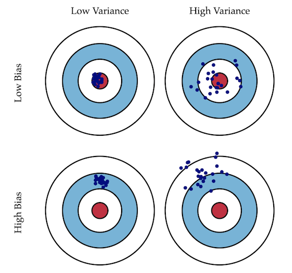

Dartboard image from a better write-up on the subject: http://scott.fortmann-roe.com/docs/BiasVariance.html

Bias: $bias(\hat\theta) = E(\hat\theta) - \theta$

Bias is the distance between the predicted value of the model and the actual value. If we repeatedly run the model on samples of the dataset, how far off on average are the predictions from the actual values?

In the dart board example, high bias would indicate that our darts (predictions) are all concentrated around some point on the board far away from the bullseye (the actual value).

Variance: $Var(\hat\theta) = \frac{\sum(\hat\theta - \theta)^{2}}{N}$

Variance is the average squared deviation of our observations from their expected value. It is a way to measure how spread out our predictions are compared to the actual values.

In the dart board example, high variance would indicate that our darts might be concentrated around the bullseye, but they are spread widely around it.

When building machine learning models, our goal is to use enough information from our training data to build a model that accurately predicts new observations. When we overfit our model to the training data, we might mistake noise for signal and make assumptions about new observations that we don’t have enough evidence to make. This is a case of high variance.

If we are too careful and don’t introduce enough information while training our model, we may miss out on important signals and make inaccurate predictions. This is a case of high bias.

The bias-variance tradeoff requires carefully balancing these two types of errors to build the most accurate model possible without overfitting to the training data.

Now, onto an actual example.

## Simulated Data Example

In the following sections, we will generate simulated polynomial data, fit a series of polynomial models to the data, and then discuss the results in terms of the Bias-Variance Tradeoff.

```r
library(data.table)
library(ggplot2)
library(RColorBrewer)
set.seed(807)
generate_data = function(f, sample_size = 100){
  x = runif(sample_size, min=-4, max=5)
  y = f(x) + rnorm(sample_size, mean=0, sd=30)
  data.table(x,y)
}

f = function(x) {x^4 - x^3 + 2*x^2 - x + 5}

dat = generate_data(f, sample_size = 200)
```

Here we see a plot of our generated data. It forms a pretty obvious U-shape, so whatever model we build will need to be able to properly fit this shape.

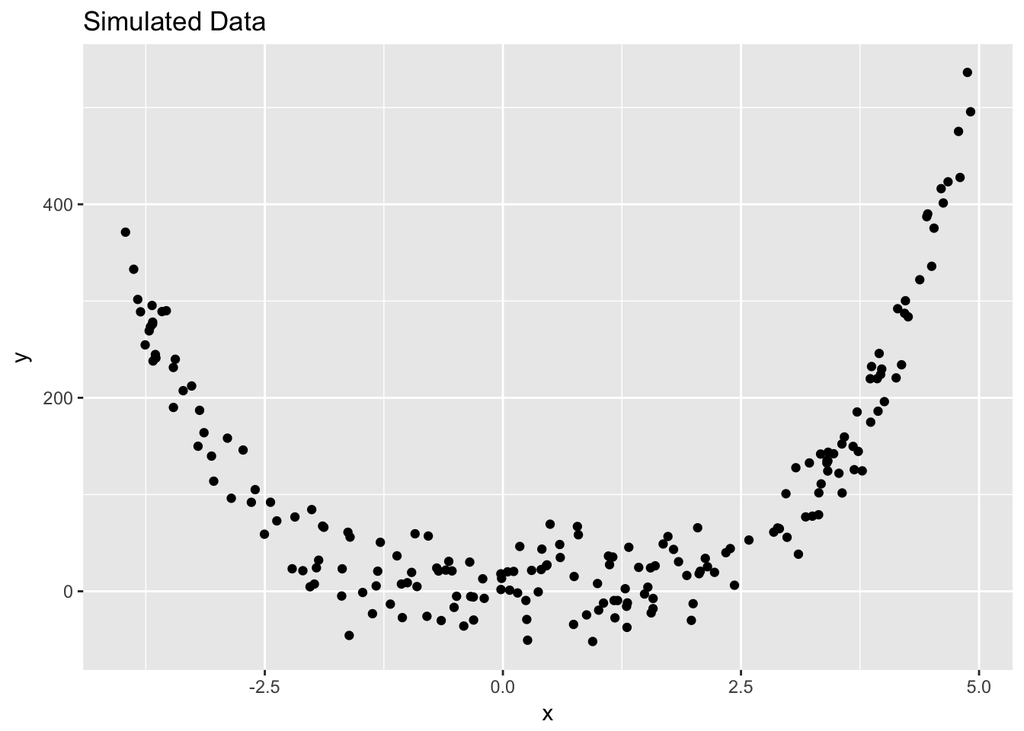

Next we need to split our data into training and test sets. This will allow us to measure bias and variance (there’s no way to tell if we are overfitting if we don’t have previously unobserved data to test with). We will use 70% of the data to train, and the remaining 30% as our test set.

```r
# create training and test datasets
smp = sample(x = 1:nrow(dat), size = round(.7*nrow(dat)), replace = F)
train = dat[smp,]
test = dat[-smp,]
```

Next, we will plot our training points in black, and our test points in red. We will build 3 polynomial models to compare: 1 degree (linear), 4-degree, and 25-degree. We plot each of these models to observe how the fluctuations in the model compare to the training data.

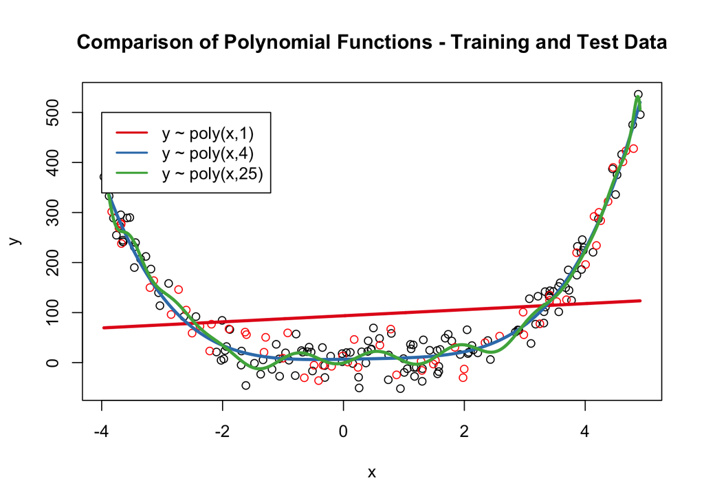

```r
# fit 3 models to the training data.  One underfit, one overfit, and one with 4 degree polynomial
plot(y~x, data=train, col='black', cex=1, pch=1)
points(y~x, data=test, col='red', cex=1, pch =1)
grid = seq(from = min(train$x), to = max(train$x), by = 0.01)

#display.brewer.all(3) # display color brewer palettes with n values
colors = brewer.pal(n=5, name="Set1")
j=1
for (i in c(1,4,25)){
  grid_predict = data.frame(x=grid)
  mod = lm(y~poly(x, degree=i), data=train)
  lines(grid, predict(mod, newdata=grid_predict), col=colors[j], lwd=3, lty=1)
  assign(paste0("model_",i), mod)
  j = j+1
}
title("Comparison of Polynomial Functions - Training and Test Data")
legend(x=-4, y =500,
       legend = c("y ~ poly(x,1)", "y ~ poly(x,4)", "y ~ poly(x,25)"),
       col=colors, lty=1, lwd=2)
```

The 25-degree polynomial is very strictly fit to the observed training points. It bounces around from point to point rather than just following the general trend in the data. This is an obvious case of overfitting, so we would expect high variance and low bias.

As expected, the 4-degree polynomial tracks the training data very well, since we know it is the best choice of model in this case. Just by looking at the plot we can see this is the optimal choice in terms of bias and variance - we are not overfitting our training data, and our predictions are pretty good on the test set.

Finally, I want to visualize the Bias-Variance tradeoff in one more way. This is a pretty common plot in text books, which shows the MSE for the training and test sets as model complexity increases. The more complex the model, the more likely it will overfit the data and have high variance.

## Bias Variance Tradeoff Plot - MSE vs. Model Complexity

In this plot, we will see that the MSE for the training set will always decrease as model complexity increases. This is a trivial point; if we’ve built a model that fits every single point in the training data perfectly, we would have MSE=0.

Something different happens when we plot the test data MSE. Rather than a decreasing trend, we see a minimum at the optimal location of the bias-variance tradeoff - this is the point at which we minimize MSE without overfitting the training data. In other words, as the model tries to fit the training points exactly, it must also start to fit unseen test data worse.

[figure not shown]

```r
# Next, we want to run 10 models, calculate MSE on the test set, and plot: degrees vs. MSE
polys = c(2,3,4,5,8,10,15,20)
model_list = c()

for (i in 1:length(polys)){
  mod = lm(y ~ poly(x, degree=polys[i]), data=train)
  model_list[[i]] = mod
  assign(paste0("model_", polys[i]), mod)
}
```

```r
dat = data.table(polys = polys,
                 train_mse = train_mse,
                 test_mse = test_mse)
dat
```

```
##    polys train_mse  test_mse
## 1:     2 1850.1327 1565.1735
## 2:     3 1751.2183 1361.4974
## 3:     4  730.8152  737.3469
## 4:     5  725.8054  740.4520
## 5:     8  714.7927  764.6406
## 6:    10  692.2466  813.1825
## 7:    15  677.4142  889.8338
## 8:    20  637.3810  950.0927
```

Here, we can see that the 4th-degree polynomial is the model that minimizes the test MSE. We have fit the polynomial model well (reducing bias as much as possible), and we’ve avoided overfitting the training data (minimizing variance).

When building machine learning models, it is vitally important to be cognizant of the bias-variance tradeoff. If you overfit the training data, you end up having high variance and will have trouble applying your model to new sets of data. If you don’t fit the model well enough, you will have high bias and your model will not incorporate important details required to properly make predictions. There are a range of machine learning methods that automatically work to reduce variance while incorporating as much information as possible.

# Random Forest

A single decision tree can easily overfit training data. If, for example, you build a decision tree with all observations and all variables, and continue splitting until every observation is in its own terminal node, you will have completely overfit the data, reducing training MSE to 0, but your model will be worthless for new data. Generally you wouldn’t continue in this fashion, but you can see where it might be easy to overfit here.

The random forest uses several methods to help with the Bias Variance Tradeoff.

1. Ensemble of Trees: rather than a single tree, a random forest builds a large number of decision trees and averages the final predictions. Generally, 500 trees are built as a starting point. This value can be tuned, but generally is a pretty good number.
2. Shallow Trees: Random forest generally uses shallower trees than you would build for decision trees, since it doesn’t need more depth to make better predictions (and reduce bias), you can just make more trees (although you probably won’t need to)!
3. Randomization: Random forest randomly selects observations (with replacement) for each tree, and variables at each split. This keeps the algorithm from favoring certain observations or variables and allows it to find less valuable splitting criteria. This clearly helps to avoid overfitting and gives the added bonus of out-of-bag samples - the resampling method holds out about 1/3 of observations from the initial datasetin each tree which can be used to calculate out-of-bag error. It has been shown that out-of-bag error estimates are unbiased, so we are able to include more data in the training set (if desired).